# 分析年齡、性別及貧富與鐵達尼號乘客的死亡關係

R05228007王翊芬、B03801053劉倢如、R06541132林憲瑋

# 題目:分析年齡、性別及貧富與鐵達尼號乘客的死亡關係

資料：鐵達尼乘客資料

# 以區段分析

將資料以分段的方式描述年齡、性別及貧富與鐵達尼號乘客的死亡關係，首先找出四項內部因子，分別為姓名、年齡、票價及存活率進行分析，並將年齡分為三區間(0-20歲)、(20-60歲)、(60-100歲)，及票價分四區間(0-100)、(100-150)、(150-200)、(200-250)

## 讀取資料

```r
Titanic <- read.csv("data/titanic.csv", header=T, sep=",")
```

## 資料整理

```r
Titanic <- Titanic[!is.na(Titanic$age)& !is.na(Titanic$fare),] #刪除NA資料
Titanic <- Titanic[!(Titanic$fare == 9999),] #刪除票價無意義的資料

#將數值資料轉為類別項目
gender <- factor(Titanic$gender)
survival <- factor(Titanic$survival)

Titanic$fare <- cut(Titanic$fare , c(0,100,150,200,250)) #將票價分區段統計
Titanic$age <- cut(Titanic$age , c(0,20,60,100)) #將年分區段統計
```

## 敘述統計

交叉比對各類別項目之間的關係

### 性別與年齡之間的關係

由年齡組成中，可發現年齡介於20-60歲佔最多數(約73%)，而0-20歲間之年輕人次之(約24%)，而在性別角度上分析，可發現整艘船男性多於女性，與看完電影中之想像不一樣，在年齡介於20-60歲之中，男性更是多於女性將近兩倍數量

```r
table(Titanic$gender,Titanic$age)
```

```
##
##     (0,20] (20,60] (60,100]
##   0    183     618       25
##   1    130     320        9
```

### 性別與票價之間的關係

```r
table(Titanic$gender,Titanic$fare)
```

```
##
##     (0,100] (100,150] (150,200] (200,250]
##   0     801        14         3         8
##   1     407        18        10        13
```

### 年齡與票價的關係

由年齡與票價間，票價介於0-100佔大多數(約95%)，也發現有較多能力購買票價高於100者，多介於20-60歲區間內，約佔83%，可享受更高之品質服務

```r
table(Titanic$age,Titanic$fare)
```

```
##
##            (0,100] (100,150] (150,200] (200,250]
##   (0,20]       301         4         3         2
##   (20,60]      871        28        10        17
##   (60,100]      30         0         0         2
```

### 尋找性別與存活之間的關係

```r
table(Titanic$gender,Titanic$survival)
```

```
##
##       0   1
##   0 662 170
##   1 143 316
```

### 尋找年齡與存活之間的關係

而由年齡與存活率之關係中，年齡介於0-20之死亡率為62%，20-60之死亡率為62%，60-100間之死亡率則為79%，可得知年紀大於60歲者之死亡率較高，但在年齡0-20與20-60間並沒顯著差異

```r
table(Titanic$age,Titanic$survival)
```

```
##
##              0   1
##   (0,20]   193 120
##   (20,60]  579 359
##   (60,100]  27   7
```

### 票價與存活之間的關係

由票價及生存率比例可得知，在票價為(200-250)之存活率高達一半以上(57%)，票價(150-200)之存活率為(69%)，(100-150)之票價存活率為(78%)，但票價介於(0-100)中之生存率僅35%，可顯示越富有之條件者，所能獲得生存機率比起貧窮者高(有能力購買票價100以上者僅66人，票價100以下則共有1208人)

```r
table(Titanic$fare,Titanic$survival)
```

```
##
##               0   1
##   (0,100]   782 426
##   (100,150]   7  25
##   (150,200]   4   9
##   (200,250]   9  12
```

# 以連續性的資料分析

## 讀取檔案

```r
titanic <- read.csv("data/titanic.csv", header=T, sep=",")
```

## 年齡、性別與存活率的關係

### 資料清理

```r
titanic <- titanic[!(titanic$age == 9999 ),] #刪除不具意義的年齡資料
```

### 樞紐分析

```r
bg_sur <- aggregate(titanic$name,by=list(titanic$age,titanic$survival,titanic$gender),length) #樞紐分析，根據年齡 存活率 及性別計算各類別人數
bg_sur[1,] #欄位格式跑掉，需重新命名
```

```
##   Group.1 Group.2 Group.3 x
## 1       1       0       0 4
```

### 資料彙整

```r
names(bg_sur) <-c("age", "survival", "gender","pops") #重新命名資料欄位
bg_sur$groups <- paste0(bg_sur$survival,bg_sur$gender) #將存活率以及性別歸類，共分為四類(男存活,男死亡,女存活,女死亡)
head(bg_sur)
```

```
##   age survival gender pops groups
## 1   1        0      0    4     00
## 2   2        0      0    3     00
## 3   4        0      0    3     00
## 4   5        0      0    3     00
## 5   6        0      0    1     00
## 6   7        0      0    2     00
```

### 繪圖

以圖呈現性別及年齡對於死亡之間的關係，可見男性死亡人數遠高於女性，但在存活人數方面而言，女性則高於男性

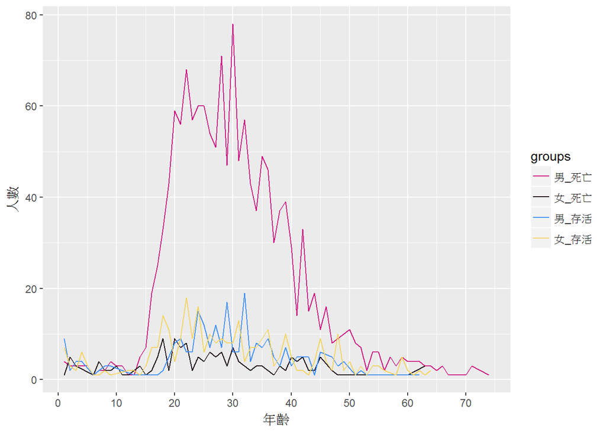

```r
library(ggplot2)
ggplot(data=bg_sur, aes(x=age, y=pops, group=groups, colour = groups)) +
  geom_line()+
  scale_color_manual(labels = c("男_死亡","女_死亡","男_存活","女_存活"),values=c("#CE1483", "#190113","#3F8FFF","#F4D35E"))+
  scale_x_continuous(breaks = seq(0,80,10))+
  xlab("年齡") +
  ylab("人數")
```

## 貧富與存活率的關係

### 資料清理

```r
titanic_f <- titanic[!(titanic$fare ==9999),]#刪除不具意義的船艙票價資料
```

### 樞紐分析

```r
fare_sur <- aggregate(titanic_f$name,by=list(titanic_f$fare,titanic_f$survival),length)#樞紐分析，根據票價及存活率計算各類別人數
names(fare_sur) <-c("fare","survival","pops")#重新命名
fare_sur[1,]
```

```
##   fare survival pops
## 1    4        0    1
```

### 繪圖

[figure not shown]

```r
fare_sur$survival <-factor(fare_sur$survival) #將數值轉為因子

ggplot(data=fare_sur, aes(x=fare, y=pops, group=survival, colour = survival)) +
  geom_line()+
  scale_color_manual(label = c("男","女"), values=c("#CE1483", "#190113"))+
  scale_x_continuous(breaks = seq(0,550,50))+
  xlab("票價") +
  ylab("人數")
```